# Elaboração de Projetos de Extensão Rural · Da Concepção à Defesa Pública

Extensão Rural

Prof. Dr. Luiz Diego Vidal Santos

## Abertura Visão Geral da Aula

Roteiro da aula Tópicos estruturantes

- 1 Concepções de Projeto em Extensão
- 2 Diagnóstico e Identificação de Demandas
- 3 Estrutura do Projeto (Problema, Objetivos, Metas)
- 4 Estratégia Metodológica
- 5 Orçamento e Cronograma
- 6 Monitoramento, Avaliação e Defesa Pública

Objetivo central Do diagnóstico à defesa pública

Capacitar o estudante de ciências agrárias para a elaboração, execução e avaliação de projetos de extensão rural voltados à agricultura familiar, desde a identificação do problema até a defesa pública da proposta.

DRP Participativo Metas SMART · Gantt Marco Lógico · PRONAF

Coerência metodológica entre demanda territorial, planejamento operacional e avaliação participativa.

# Concepções e Diagnóstico Participativo

## Projetos Concepções e Fontes de Financiamento em ATER

**Coelho (2014):** projetos de extensão rural diferenciam-se de projetos de pesquisa e investimento por sua **natureza interventiva e educativa**, promovendo mudanças concretas via participação e ação coletiva.

Tipologia de atuação Tipos de projetos em ATER

- **Assessoria técnica:** orientação produtiva a grupos para melhoria de sistemas específicos
- **Desenvolvimento comunitário:** organização social, acesso a mercados e infraestrutura
- **Pesquisa-ação participativa:** geração de conhecimento com agricultores como co-pesquisadores
- **Formação:** capacitação de multiplicadores locais em temas técnicos e organizativos

Captação e fomento Fontes de financiamento

- Chamadas Públicas de ATER (ANATER e governos estaduais)
- Editais de extensão universitária (PROEX, MEC)
- Emendas parlamentares e convênios governamentais
- Cooperação internacional (FAO, FIDA, GIZ)
- Sistema S (SENAR, SEBRAE), fundações e OSCs

## Projetos Ciclo de Projetos de Extensão e Marco Lógico

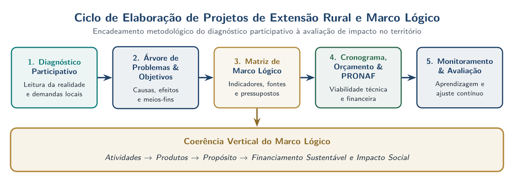

Ciclo completo de elaboração de projetos de extensão rural em cinco etapas e coerência vertical do Marco Lógico.

Ciclo de Elaboração de Projetos de Extensão Rural e Coerência do Marco Lógico 1. Diagnóstico Participativo → 2. Árvore de Problemas & Objetivos → 3. Matriz de Marco Lógico → 4. Cronograma, Orçamento & PRONAF → 5. Monitoramento & Avaliação

## Diagnóstico Diagnóstico Participativo e Ferramentas do DRP

**Verdejo (2006) e Kummer (2007):** o diagnóstico não é mera coleta extrativa de dados, mas leitura participativa da realidade com os agricultores como sujeitos; o **DRP** (adaptado do *PRA*) é sua principal caixa de ferramentas.

01 · Mapa Falante Leitura espacial

Comunidade desenha seu território, localizando recursos naturais, áreas produtivas, infraestrutura e problemas ambientais.

02 · Linha do Tempo Trajetória histórica

Reconstrói marcos de transformação produtiva, climática e organizativa vividos pela comunidade.

03 · Diagrama de Venn Rede institucional

Mapeia instituições, sindicatos e organizações atuantes no território e a força de seus vínculos locais.

04 · Caminhada Transversal Observação em transecto

Percurso em campo com moradores observando solos, relevo, cobertura vegetal e usos produtivos.

05 · Matriz FOFA / SWOT Síntese estratégica

Organiza Forças, Oportunidades, Fraquezas e Ameaças levantadas para orientar prioridades do projeto.

06 · Calendário Sazonal Dinâmica anual

Identifica padrões mensais de chuvas, trabalho, produção, renda e períodos críticos de vulnerabilidade.

## Diagnóstico Caixa de Ferramentas do Diagnóstico Participativo

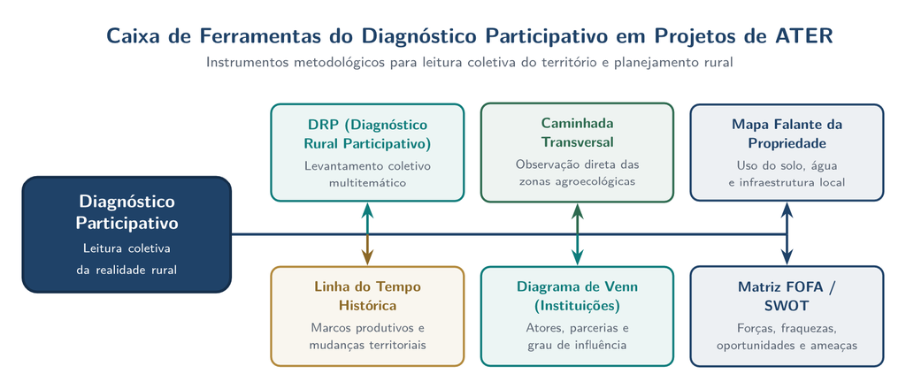

Ferramentas Participativas de Diagnóstico em Projetos de Extensão Rural Combinação de ferramentas espaciais, temporais, relacionais e estratégicas no DRP (Verdejo, 2006; Kummer, 2007)

O cruzamento de ferramentas visuais com diferentes grupos (mulheres, jovens e idosos) reduz vieses e qualifica o levantamento de demandas do projeto.

# Estrutura, Problema e Metas

## Estrutura Encadeamento Lógico do Projeto de Extensão

01 · Problema O que resolver?

Situação concreta delimitada e comprovada no diagnóstico.

02 · Justificativa Por que importa?

Relevância social, econômica, ambiental e respaldo legal.

03 · Objetivos O que alcançar?

Mudança geral pretendida e desdobramentos específicos.

04 · Metas Quanto e quando?

Quantificação objetiva em prazo e magnitude (SMART).

05 · Metodologia Como fazer?

Métodos participativos coerentes com a PNATER.

06 · Cronograma Quando agir?

Sequência temporal e dependências (Gráfico de Gantt).

07 · Orçamento Com quais recursos?

Rubricas detalhadas, justificadas e viáveis.

08 · Avaliação Como medir?

Indicadores quantitativos e qualitativos participativos.

A força de uma proposta reside na **coerência interna**: cada objetivo específico deve dialogar com uma meta, um método, uma rubrica e um indicador.

## Estrutura Formulação do Problema e da Justificativa

Delimitação espacial e temporal O Problema refinado

Evitar fórmulas genéricas (“baixa produtividade” ou “falta de ATER”); o problema precisa ser específico, mensurável e ancorado no diagnóstico.

**Exemplo refinado:** *“Os 45 agricultores familiares do assentamento Nova Esperança (município X, SE) apresentam perda média de 30% da produção de hortaliças por manejo fitossanitário inadequado, comprometendo a renda familiar e o abastecimento da feira local.”*

Argumentação técnica e política · Coelho (2014) A Justificativa

Responde *“por que esse problema merece atenção?”* articulando:

- Dados empíricos locais obtidos no DRP
- Referências científicas da literatura agronômica
- Marcos legais pertinentes (**PNATER**, **LOSAN**, **PNAPO**)
- Relevância social, econômica e ambiental para convencer o financiador ou órgão de ATER

## Estrutura Objetivos e Metas SMART

Verbo no infinitivo Objetivo Geral

Expressa a mudança ampla em coerência direta com o problema: *“Promover o manejo agroecológico de hortaliças no assentamento Nova Esperança, reduzindo perdas produtivas e fortalecendo a comercialização na feira local.”*

Desdobramento operacional Objetivos Específicos

Decompõem o objetivo geral em ações concretamente alcançáveis na vigência do projeto, gerando metas e indicadores verificáveis.

**Critério SMART:** *Specific* (específica), *Measurable* (mensurável), *Achievable* (alcançável), *Relevant* (relevante) e *Time-bound* (temporal).

**Meta 1:** Capacitar **45 agricultores** em manejo integrado de pragas até o **mês 3**.

**Meta 2:** Implantar **15 unidades demonstrativas** de horticultura agroecológica até o **mês 5**.

**Meta 3:** Reduzir em **20%** as perdas por fitossanidade até o **mês 10**.

**Meta 4:** Inserir **10 novos produtores** na feira local até o **mês 12**.

# Metodologia, Orçamento e Cronograma

## Metodologia Estratégia Metodológica Participativa

| Método | Descrição | Quando Usar |
| --- | --- | --- |
| **Oficinas participativas** | Atividades práticas com grupos de agricultores | Capacitação em manejo e processamento |
| **Unidades demonstrativas** | Áreas experimentais em propriedades | Validação de tecnologias adaptadas |
| **Intercâmbio agricultor-agricultor** | Visitas entre produtores de diferentes regiões | Troca de experiências e motivação |
| **Dias de campo** | Eventos abertos com demonstrações práticas | Difusão ampliada de resultados |
| **Assistência técnica individual** | Visitas às propriedades com orientação sob medida | Acompanhamento de casos específicos |
| **Produção de material didático** | Cartilhas, vídeos, folders | Suporte às atividades de formação |

Em coerência com a **PNATER**, métodos participativos devem prevalecer sobre abordagens puramente transmissivas (Caporal e Costabeber, 2004).

## Metodologia Produção de Material Didático no Projeto

Adequação comunicacional · Coelho (2014) Linguagem e visualidade

Para agricultores com baixa escolaridade, priorizar fotografias, ilustrações e esquemas com textos curtos, diretos e aplicáveis à rotina produtiva.

Múltiplos suportes Formatos na ATER contemporânea

Cartilhas técnicas ilustradas, folders e panfletos, vídeos instrucionais, podcasts e programas de rádio, cadernos de campo e materiais digitais para celular.

**1. Linguagem acessível:** evitar jargão acadêmico excessivo.

**2. Riqueza visual:** fotos reais da comunidade e esquemas claros.

**3. Conteúdo prático:** orientações passo a passo aplicáveis em campo.

**4. Diversidade cultural:** respeito às expressões e saberes locais.

**5. Meio adequado:** impresso, digital ou rádio conforme acesso local.

**6. Co-produção:** elaborar e validar com os agricultores sempre que possível.

## Operação Orçamento e Cronograma (Gráfico de Gantt)

Viabilidade financeira Rubricas do Orçamento

Organizadas segundo as regras do financiador:

- **Recursos humanos:** bolsas, diárias e honorários
- **Material de consumo:** insumos, sementes e escritório
- **Equipamentos / permanente**
- **Serviços de terceiros:** gráfica, transporte e audiovisual
- **Deslocamentos** (combustível, passagens) e custos administrativos

| Atividade (Gantt) | M1 | M2 | M3 | M4 | M5 | M6 |
| --- | --- | --- | --- | --- | --- | --- |
| Diagnóstico (DRP) | X | X |  |  |  |  |
| Oficinas de capacitação |  | X | X | X |  |  |
| Unidades demonstrativas |  |  | X | X | X |  |
| Dias de campo |  |  |  |  | X |  |
| Avaliação e relatório |  |  |  |  | X | X |

Clareza orçamentária e realismo no **Gráfico de Gantt** são fatores decisivos para aprovação em editais e crédito rural (como **PRONAF** / chamadas de ATER).

# Monitoramento, Marco Lógico e Defesa

## Avaliação Ciclo de Monitoramento e Avaliação (M&A)

**1. Planejamento:** definição prévia de metas, linha de base e indicadores.

**2. Execução:** realização das atividades previstas no cronograma.

**3. Monitoramento:** acompanhamento contínuo da entrega e do ritmo das ações.

**4. Avaliação:** análise dos resultados alcançados frente aos objetivos e metas (Rua, 2009).

**5. Retroalimentação:** ajustes de rota e aprendizados devolvidos diretamente à execução.

Rua (2009) Monitorar ≠ Avaliar

O **monitoramento** verifica continuamente *se estamos fazendo conforme planejado*; a **avaliação** analisa *quais resultados e transformações foram efetivamente produzidos*.

Coerência com a PNATER Avaliação participativa

Envolve os próprios agricultores na leitura dos resultados, combinando dados numéricos e dimensões qualitativas de autonomia.

## Ciclo M&A Fluxo Contínuo de Monitoramento e Avaliação

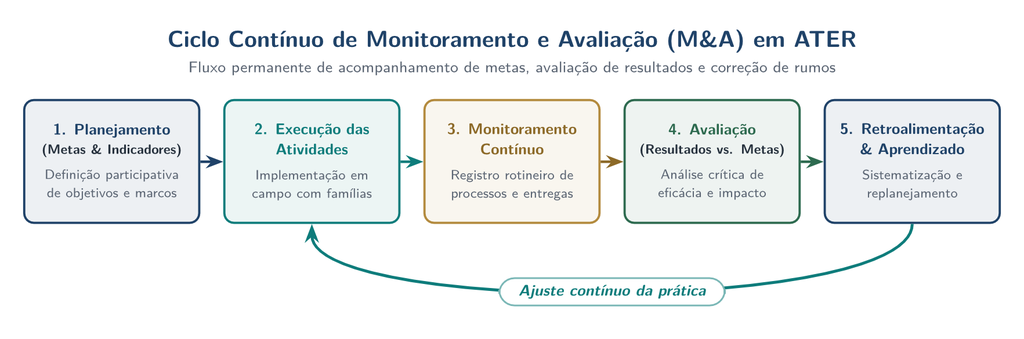

Ciclo Contínuo de Monitoramento e Avaliação (M&A) em Projetos de ATER Retroalimentação permanente entre planejamento, execução em campo, monitoramento e avaliação de resultados

**Gestão adaptativa:** o monitoramento acompanha processos durante a execução; a avaliação verifica transformações e retroalimenta o replanejamento com as famílias.

## Avaliação Indicadores Quantitativos e Qualitativos

Mensuração objetiva Indicadores Quantitativos

Permitem comparações numéricas diretas ao longo do projeto:

- Número de agricultores capacitados
- Área implantada sob manejo agroecológico
- Variação percentual de produtividade e renda
- Volume de produção comercializado
- Número de organizações comunitárias fortalecidas

Efetividade transformadora Indicadores Qualitativos

Captam dimensões não reduzíveis a números:

- Grau de participação nas decisões do projeto
- Percepção de mudança na qualidade de vida
- Fortalecimento de redes de cooperação entre produtores
- Autonomia decisória dos beneficiários
- Satisfação com os serviços de ATER

Projetos robustos equilibram **metas físicas entregues** com **evidências de apropriação e autonomia comunitária**.

## Marco Lógico Modelo de Marco Lógico (Logical Framework)

| Nível Hierárquico | Descrição | Exemplo em Projeto de ATER |
| --- | --- | --- |
| **Objetivo Superior** | Mudança de longo prazo à qual o projeto contribui | Melhoria da SAN no território |
| **Objetivo do Projeto** | Mudança direta que o projeto produz | Agricultores adotam manejo agroecológico |
| **Resultados** | Produtos e serviços entregues pelo projeto | 15 unidades demonstrativas implantadas |
| **Atividades** | Ações concretas para alcançar os resultados | Oficinas, visitas técnicas, dias de campo |

Para cada nível definem-se **indicadores verificáveis**, **fontes de verificação** e **pressupostos** (condições externas) — padrão amplamente exigido por **FAO**, **FIDA** e **GIZ**.

## Defesa Defesa Pública da Proposta

Comunicação em banca ou comunidade Estrutura da apresentação

- **Abertura:** contextualiza o problema e o território
- **Desenvolvimento:** apresenta objetivos, metodologia, cronograma e orçamento
- **Fechamento:** sintetiza resultados esperados e contribuições sociais
- **Arguição:** diálogo fundamentado com banca examinadora ou comunidade

**1.** Pertinência e clareza na delimitação do problema

**2.** Coerência lógica entre problema, objetivos e metodologia

**3.** Viabilidade real do orçamento e do cronograma

**4.** Uso consistente de métodos participativos

**5.** Qualidade do material de apoio produzido

**6.** Capacidade de argumentação e resposta na arguição

## Síntese Conclusão e Referências

**Síntese:** um projeto de extensão rural consistente articula diagnóstico participativo, fundamentação teórica e legal, planejamento operacional factível e avaliação dialógica voltada à transformação das condições de vida no campo.

Bloco 1 · Metodologia e Projetos Base técnica e participativa

- Caporal, F. R.; Costabeber, J. A. *Agroecologia e Extensão Rural: contribuições para o desenvolvimento rural sustentável*. Brasília: MDA/IICA, 2004.
- Coelho, F. M. G. *A Arte das Orientações Técnicas no Campo*. Rio Branco: Suprema, 2014.
- Kummer, L. *Metodologia Participativa no Meio Rural: uma visão interdisciplinar*. Salvador: GTZ, 2007.
- Rua, M. G. *Avaliação de Políticas, Programas e Projetos: notas introdutórias*. Brasília: ENAP, 2009.
- Verdejo, M. E. *Diagnóstico Rural Participativo: guia prático DRP*. Brasília: MDA/SAF, 2006.

Bloco 2 · Marcos Legais Referências normativas brasileiras

- Brasil. *Lei 12.188/2010*. PNATER/PRONATER (2010).
- Brasil. *Lei 11.346/2006*. Lei Orgânica de Segurança Alimentar (LOSAN).
- Brasil. *Decreto 7.794/2012*. Política Nacional de Agroecologia e Produção Orgânica (PNAPO).

Obrigado!

Luiz Diego Vidal Santos

Universidade Estadual de Feira de Santana (UEFS)